# BIOSTAT702 R Tutorial 4:

Simple Linear Regression with a Categorical Predictor

Marissa Ashner, PhD

Last Updated: 2024-09-10

This tutorial will follow closely with parts of Chapters 4 and 5 in the [textbook](https://bookdown.org/rwnahhas/RMPH/datasumm.html).

# Packages

The following code loads the packages you need for the tutorial.

```r
## NOTE: If you do not have a package installed, you must install it first
# For example, you can run the following code if you don't have the gtsummary package:
# install.packages("gtsummary")


# for navigating within the R project
library(here)

# for data wrangling
library(tidyverse)

# for nice-looking tables
library(gtsummary)

# for ANOVA tests / diagnostics
library(car)
library(olsrr)

# for contrasts
library(doBy)
```

# Resources

Below is a list of resources that may be helpful or provide more information on this topic.

- [Guide to Regression Diagnostics with R](https://sscc.wisc.edu/sscc/pubs/RegDiag-R/index.html)

# Load Data

The dataset used for this tutorial is loaded here.

```r
# Load Data
# will be called "nhanes_adult_exam_sub" in your environment
load(here("data/nhanes1718_adult_fast_sub_rmph.Rdata"))

# rename dataset for convenience
nhanesf <- nhanes_adult_fast_sub
```

# Visualize the Data

From the NHANES dataset, we will investigate how the mean fasting glucose varies with smoking status (categorical variable). The first thing to do is visualize the data.

## Visualizing the Distribution of the Predictor

Rather than visualizing the distribution of the predictor, we can simply look at the number in each group using a table.

```r
table(nhanesf$smoker, useNA = "ifany")
```

```
##
##   Never    Past Current
##     579     264     157
```

## Visualizing the Relationship between the Predictor and Outcome

When the predictor is categorical, rather than fitting a straight line across all values, simple linear regression estimates the mean outcome at each level of the predictor. We can visualize this using boxplots.

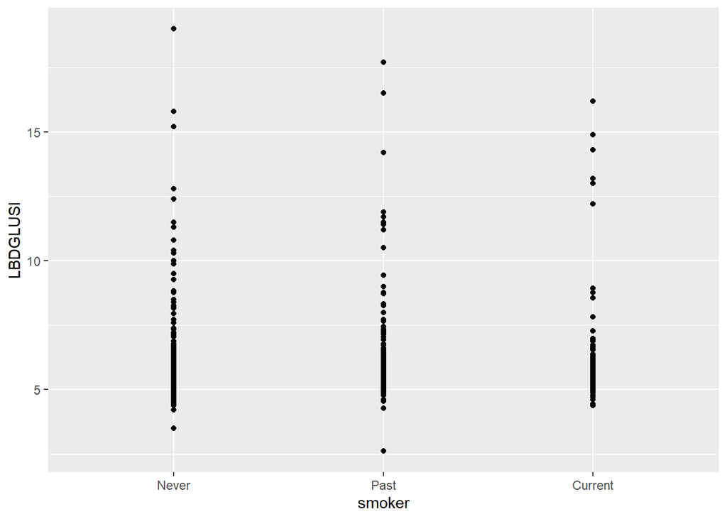

```r
# Plot the scatterplot
ggplot(data = nhanesf) + geom_point(aes(smoker, LBDGLUSI))
```

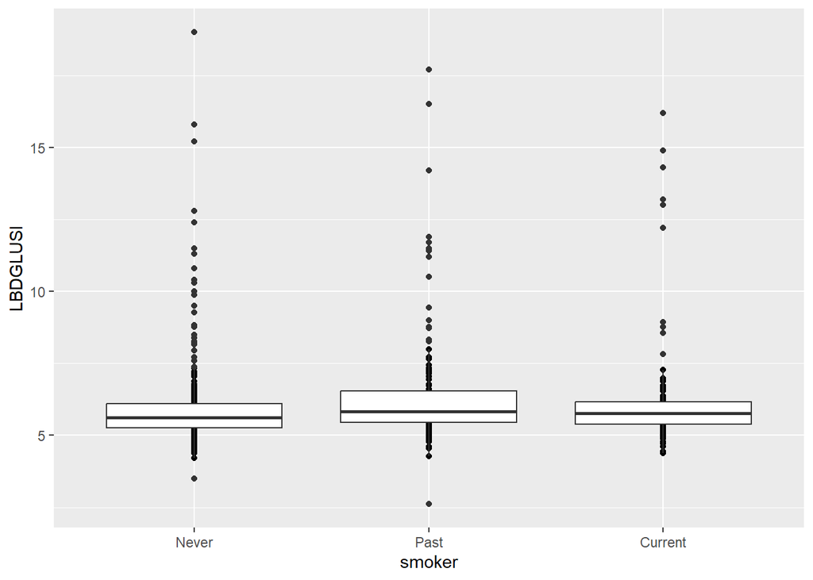

```r
# Plot the scatterplot with an appended means and connected lines
ggplot(data = nhanesf, aes(smoker, LBDGLUSI)) + geom_point() +
  geom_boxplot()
```

# Fitting the Linear Model

We can still run the `lm()` function to fit a simple linear regression model with a categorical predictor in the same way we would with a continuous predictor. Make sure your predictor is a factor variable before fitting the linear model. If it is not, you can use the `as.factor()` function to convert it. You can see that there are three regression coefficients total instead of just two. That is because R automatically creates dummy variables when a categorical predictor is input to the model.

```r
# check class of predictor
class(nhanesf$smoker)
```

```
## [1] "factor"
```

```r
# fit the model
fit1 <- lm(LBDGLUSI ~ smoker, data = nhanesf)

# output the results
summary(fit1)
```

```
##
## Call:
## lm(formula = LBDGLUSI ~ smoker, data = nhanesf)
##
## Residuals:
##     Min      1Q  Median      3Q     Max
## -3.7523 -0.7223 -0.3674  0.1677 13.0577
##
## Coefficients:
##               Estimate Std. Error t value Pr(>|t|)
## (Intercept)     5.9423     0.0666  89.229  < 2e-16 ***
## smokerPast      0.4199     0.1190   3.529 0.000437 ***
## smokerCurrent   0.2551     0.1442   1.769 0.077220 .
## ---
## Signif. codes:  0 '***' 0.001 '**' 0.01 '*' 0.05 '.' 0.1 ' ' 1
##
## Residual standard error: 1.602 on 997 degrees of freedom
## Multiple R-squared:  0.0131, Adjusted R-squared:  0.01113
## F-statistic:  6.62 on 2 and 997 DF,  p-value: 0.001393
```

## Factor Levels

By default, R sets the reference level to be the first level of the predictor. You can check this using the `levels()` function if you predictor is a factor. This tells us that “Never” is the reference level.

```r
levels(nhanesf$smoker)
```

```
## [1] "Never"   "Past"    "Current"
```

If you want to change the reference level, you can use the `relevel()` function in R.

```r
nhanesf$smoker_relevel = relevel(nhanesf$smoker, ref = "Past")

fit1_relevel = lm(LBDGLUSI ~ smoker_relevel, data = nhanesf)
summary(fit1_relevel)
```

```
##
## Call:
## lm(formula = LBDGLUSI ~ smoker_relevel, data = nhanesf)
##
## Residuals:
##     Min      1Q  Median      3Q     Max
## -3.7523 -0.7223 -0.3674  0.1677 13.0577
##
## Coefficients:
##                       Estimate Std. Error t value Pr(>|t|)
## (Intercept)            6.36227    0.09863  64.510  < 2e-16 ***
## smoker_relevelNever   -0.41994    0.11900  -3.529 0.000437 ***
## smoker_relevelCurrent -0.16488    0.16150  -1.021 0.307531
## ---
## Signif. codes:  0 '***' 0.001 '**' 0.01 '*' 0.05 '.' 0.1 ' ' 1
##
## Residual standard error: 1.602 on 997 degrees of freedom
## Multiple R-squared:  0.0131, Adjusted R-squared:  0.01113
## F-statistic:  6.62 on 2 and 997 DF,  p-value: 0.001393
```

# Inference for models with a categorical predictor

You probably noticed that in the summary output for our model with a categorical predictor, we obtained multiple p-values for the smoker predictor. These come from the Wald-type t-tests run on *each* dummy variable. If you want to test the significance of the smoker predictor as a whole, rather than each dummy variable compared to the reference, you can refer to the F-statistic from the model.

Unlike for the continuous predictor model, this F-test is not equivalent to the t-tests. The F-test is a global test of significance across all predictors. When your predictor is continuous (OR binary) and there is only one coefficient aside from the intercept, these two are equivalent. Otherwise, they test different things.

## F-Test from lm()

Use the following code to get the F-test information from `lm()`.

```r
fit1_summary = summary(fit1)
fit1_summary$fstatistic
```

```
##      value      numdf      dendf
##   6.619515   2.000000 997.000000
```

## F-Test from anova()

The F-test from `lm()` will be equivalent to the one from `anova()`.

```r
anova(fit1)
```

```
## Analysis of Variance Table
##
## Response: LBDGLUSI
##            Df Sum Sq Mean Sq F value   Pr(>F)
## smoker      2   34.0 16.9983  6.6195 0.001393 **
## Residuals 997 2560.2  2.5679
## ---
## Signif. codes:  0 '***' 0.001 '**' 0.01 '*' 0.05 '.' 0.1 ' ' 1
```

## F-Test from Anova()

There is another function called `Anova()` in the `car` package that can test the significance of a categorical predictor without running a global test, using what is called a Type III test. This will be important for multivariable linear regression, but right now will get us the same answer as the other F-tests.

```r
Anova(fit1, type = 3)
```

```
## Anova Table (Type III tests)
##
## Response: LBDGLUSI
##              Sum Sq  Df   F value    Pr(>F)
## (Intercept) 20445.2   1 7961.8122 < 2.2e-16 ***
## smoker         34.0   2    6.6195  0.001393 **
## Residuals    2560.2 997
## ---
## Signif. codes:  0 '***' 0.001 '**' 0.01 '*' 0.05 '.' 0.1 ' ' 1
```

## Contrasts

Contrasts are linear combinations of the parameters in an SLR model, and we can run tests in R for these. I will show an example testing any difference between the groups (i.e., that the two non-intercept regression coefficients are both equal to 0). I usually like to use the `esticon()` function in the `doBy` package.

The hypothesis is the same being tested in the `Anova()` function above, and we can see that the p-values are almost identical.

```r
# create matrix of coefficients to test
# first row tests beta1 = 0
# second row tests beta2 = 0
L = rbind(c(0, 1, 0), c(0, 0, 1))

esticon(fit1, L, conf.int = TRUE, joint.test = TRUE)
```

```
##    X2.stat DF  Pr(>|X^2|)
## 1 13.23903  2 0.001334078
```

## Pairwise Predictions and Multiple Testing

Since the F-test comparing all three group means is statistically significant, this suggests that at least one of the three group means is different than the others, which warrants further investigation. We can also use the `esticon()` function to run 3-pairwise tests comparing each pair of group means simultaneously. The way our variable is coded,

Never Smoker: $\beta_0$ Past Smoker: $\beta_0 + \beta_1$ Current Smoker: $\beta_0 + \beta_2$

Therefore, to test the null hypothesis that never and past smoker have equal group means, we can test $\beta_0 = \beta_0 + \beta_1 \implies \beta_1 = 0$. Similarly, for never and current smoker, we can test $\beta_2 = 0$. To compare past and current smoker group means, we can test $\beta_0 + \beta_1 = \beta_0 + \beta_2 \implies \beta_1 -\beta_2 = 0$. This can help to set up our contrast matrix $L$.

```r
# create matrix of coefficients to test
# first row tests beta1 = 0
# second row tests beta2 = 0
# third row tests beta1-beta2 = 0
L = rbind(c(0, 1, 0),
          c(0, 0, 1) ,
          c(0, 1, -1))

contrast1 = esticon(fit1, L, conf.int = TRUE) %>% as.data.frame()
contrast1
```

```
##    estimate std.error statistic      p.value beta0  df         lwr       upr
## 1 0.4199411 0.1190043  3.528789 0.0004365144     0 997  0.18641343 0.6534688
## 2 0.2550569 0.1441916  1.768875 0.0772204540     0 997 -0.02789694 0.5380108
## 3 0.1648842 0.1615026  1.020938 0.3075312612     0 997 -0.15203978 0.4818082
```

Since we are running three simultaneous tests, we might want to control for Type I error by adjusting for multiple tests, using the bonferroni correction, for example. We have to adjust for this after running `esticon()`, using the `p.adjust()` function. We can adjust the CI level in the `esticon()` arguments though.

```r
contrast2 = esticon(fit1, L, conf.int = TRUE,
                    # new CI level is 1 - new significance level, which is 0.05 divided by the number of tests
                    level = 1-0.05/dim(L)[1]
                    ) %>% as.data.frame()

# adjust p values
contrast2$p.value = p.adjust(contrast2$p.value,
                             method = "bonferroni")

contrast2
```

```
##    estimate std.error statistic     p.value beta0  df         lwr       upr
## 1 0.4199411 0.1190043  3.528789 0.001309543     0 997  0.13456554 0.7053167
## 2 0.2550569 0.1441916  1.768875 0.231661362     0 997 -0.09071845 0.6008323
## 3 0.1648842 0.1615026  1.020938 0.922593784     0 997 -0.22240335 0.5521717
```

## Nice-Looking Summary Table

The `gtsummary` package can be used to create a more aesthetically pleasing table. You can then export this to a word document. You can add the Type III global test to the table as well.

```r
fit1_table <- fit1 %>%
  tbl_regression(intercept = T,
                 estimate_fun = function(x) style_sigfig(x, digits = 4),
                 pvalue_fun   = function(x) style_pvalue(x, digits = 3),
                 label        = list(smoker ~ "Smoking Status")) %>%
  add_global_p(keep = TRUE) %>%
  modify_caption("Regression of fasting glucose (mmol/L) on smoking status")
fit1_table
```

Regression of fasting glucose (mmol/L) on smoking status

| **Characteristic** | **Beta** | **95% CI**<sup>1</sup> | **p-value** |
| --- | --- | --- | --- |
| (Intercept) | 5.942 | 5.812, 6.073 | <0.001 |
| Smoking Status |  |  | 0.001 |
| Never | — | — |  |
| Past | 0.4199 | 0.1864, 0.6535 | <0.001 |
| Current | 0.2551 | -0.0279, 0.5380 | 0.077 |

<sup>1</sup> CI = Confidence Interval

```r
fit1_table %>%
  as_flex_table() %>%
  flextable::save_as_docx(path = here("04-SLRCategoricalPredictor",
                           "04-fit1table.docx"))
```

# Predictions from the Model

You can use the `predict()` function to output the predicted outcome with a certain level of the predictor. You can include a confidence interval, prediction interval, or neither. Prediction intervals are wider than confidence intervals because they account for the additional uncertainty surrounding an individual prediction, where confidence intervals describe the confidence around the mean.

```r
predict(fit1,
        newdata = data.frame(smoker = "Current"),
        interval = "confidence")
```

```
##        fit      lwr      upr
## 1 6.197389 5.946422 6.448355
```

```r
predict(fit1,
        newdata = data.frame(smoker = "Current"),
        interval = "prediction")
```

```
##        fit      lwr     upr
## 1 6.197389 3.042787 9.35199
```

We can add the confidence intervals or prediction intervals to our scatterplot as shown below.

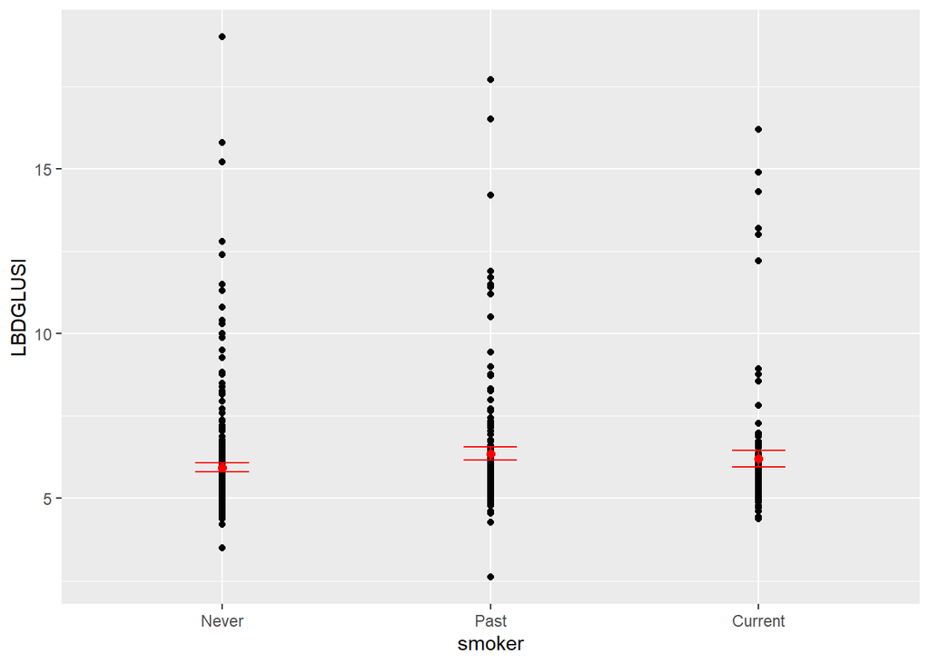

```r
# Confidence Intervals
ci_pred = predict(fit1, newdata = nhanesf,
                  interval = "confidence") %>% cbind(nhanesf)

ggplot(data = ci_pred, aes(smoker, LBDGLUSI)) + geom_point() +
  geom_point(aes(smoker, fit), color = "red", size = 2) +
  geom_errorbar(aes(ymin = lwr, ymax = upr), color = "red", width = 0.2)
```

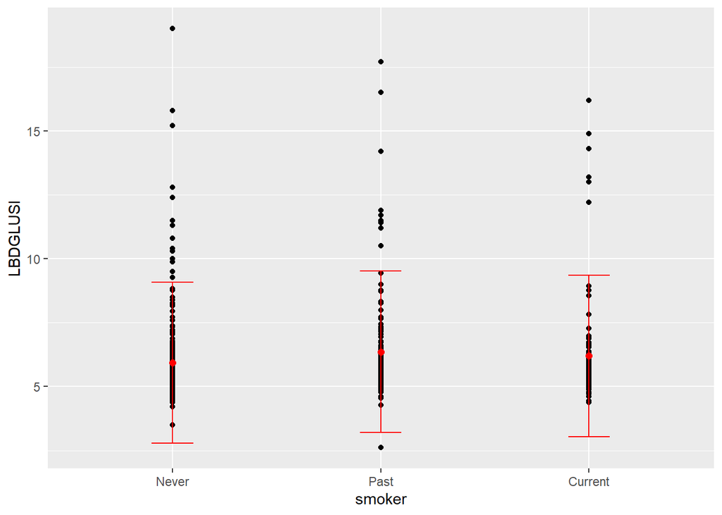

```r
# Prediction Intervals
pi_pred = predict(fit1, newdata = nhanesf,
                  interval = "prediction") %>% cbind(nhanesf)

ggplot(data = pi_pred, aes(smoker, LBDGLUSI)) + geom_point() +
  geom_point(aes(smoker, fit), color = "red", size = 2) +
  geom_errorbar(aes(ymin = lwr, ymax = upr), color = "red", width = 0.2)
```

# Residuals and Diagnostics

All residuals and diagnostic tests can be done in the same way as with a continuous predictor, with the exception of the linearity assumption, which does not need to be tested here. I use the same code as I did with the continuous predictor below to show what the output looks like with a categorical variable instead.

## Different types of Residuals

```r
# compare the three types of residuals

# compare average / quantiles
residuals_fit1 = data.frame(
  unstandardized_resid = residuals(fit1),
  standardized_resid = rstandard(fit1),
  studentized_resid = rstudent(fit1)
)
summary(residuals_fit1)
```

```
##  unstandardized_resid standardized_resid studentized_resid
##  Min.   :-3.7523      Min.   :-2.3460    Min.   :-2.35132
##  1st Qu.:-0.7223      1st Qu.:-0.4512    1st Qu.:-0.45097
##  Median :-0.3674      Median :-0.2300    Median :-0.22989
##  Mean   : 0.0000      Mean   : 0.0000    Mean   : 0.00192
##  3rd Qu.: 0.1677      3rd Qu.: 0.1047    3rd Qu.: 0.10467
##  Max.   :13.0577      Max.   : 8.1555    Max.   : 8.43772
```

```r
# compare standard deviations
apply(residuals_fit1, 2, sd)
```

```
## unstandardized_resid   standardized_resid    studentized_resid
##             1.600866             1.000733             1.011292
```

## Testing the Normality Assumption

It is recommended to test this assumption visually using QQ plots and histograms of the residuals.

### Q-Q Plot of Residuals

The closer the points are to the black line, the better the normality assumption is met.

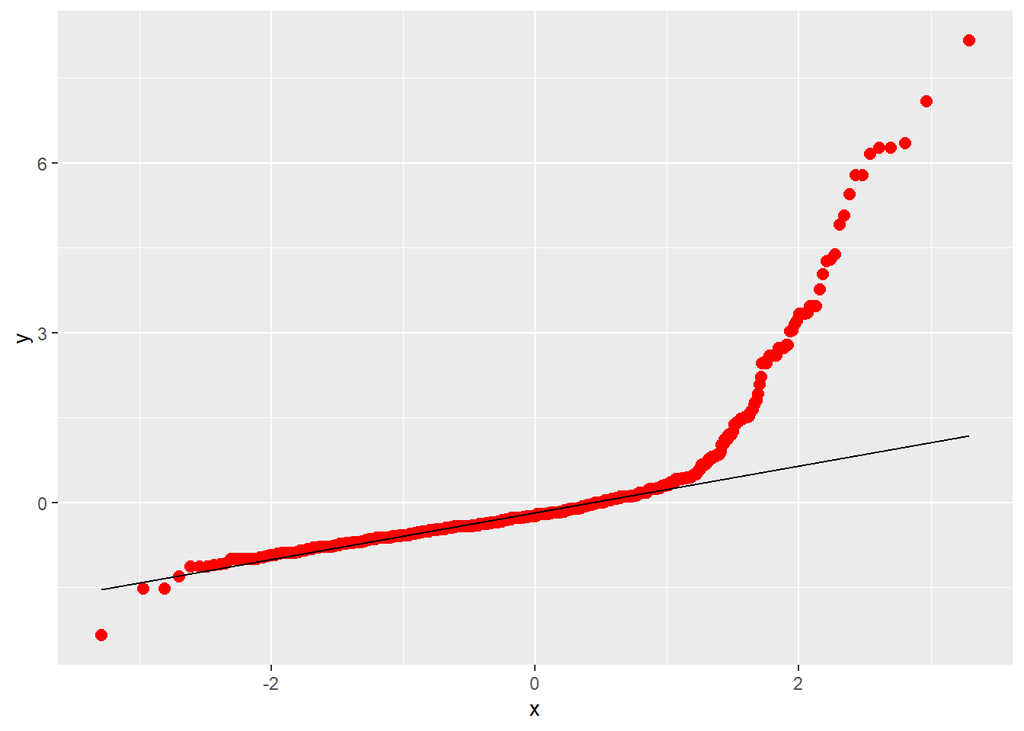

```r
ggplot(residuals_fit1, aes(sample = standardized_resid)) +
  stat_qq(size = 2.5, color = 'red') +
  stat_qq_line()
```

### Histogram of Residuals

In the histogram below, the red solid line provides a smoothed estimate of the distribution of the observed residuals. The blue dashed line is the best fit normal curve based on the mean and standard deviation of the residuals. The closer these two curves are to each other, the better the normality assumption is met.

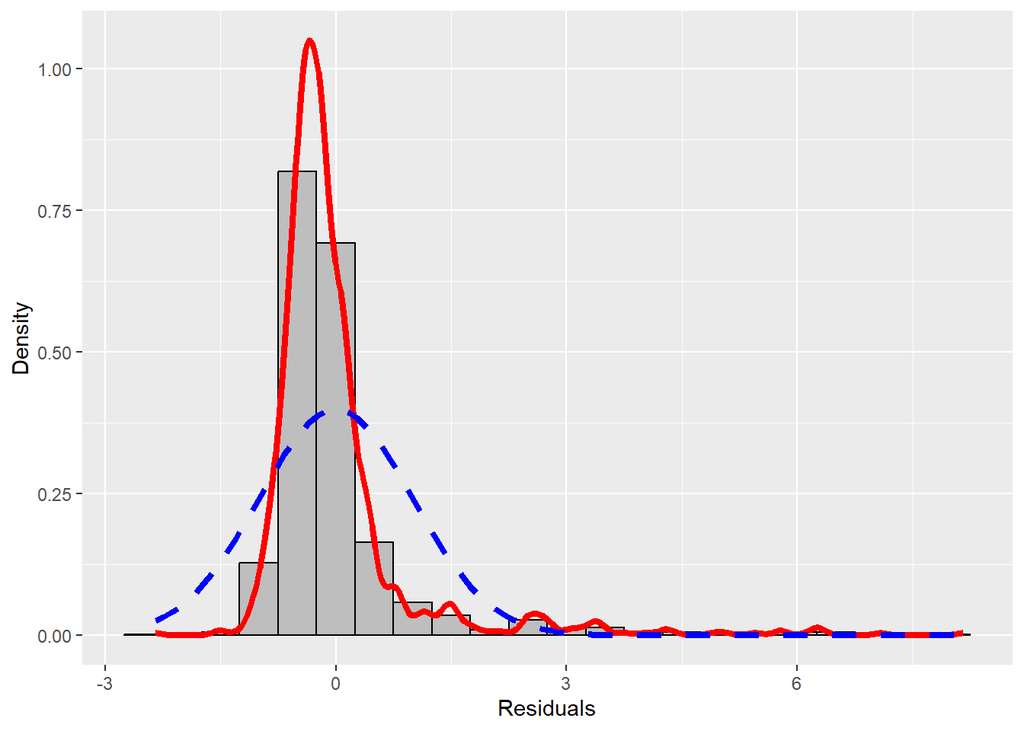

```r
# Create the histogram with the empirical density and normal curve
ggplot(residuals_fit1, aes(x = standardized_resid)) +
  geom_histogram(aes(y = ..density..), binwidth = 0.5,
                 fill = "grey", color = "black") +
  geom_density(color = "red", size = 1.5) +
  stat_function(fun = dnorm,
                args = list(mean = mean(residuals_fit1$standardized_resid, na.rm = TRUE),
                            sd = sd(residuals_fit1$standardized_resid, na.rm = TRUE)),
                color = "blue", linetype = "dashed", size = 1.5) +
  labs(x = "Residuals", y = "Density")
```

## Testing the Constant Variance Assumption

You can plot the residuals vs the fitted values (or the predictors themselves) to see if the spread of residuals varies across the fitted values. This can be done in R using the `residualPlots()` function in the `car` package.

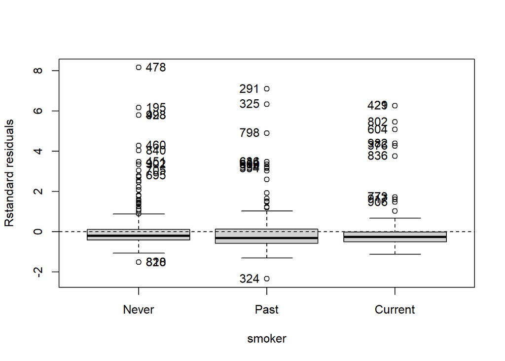

```r
# fitted = T requests the residual vs. smoker plot
# tests = F and quadratic = F suppresses hypothesis tests
residualPlots(fit1,
              pch=20, col="gray", type = "rstandard",
              fitted = F, tests = F, quadratic = F)
```

# Outliers

An outlier in simple linear regression is an observation with a very large residual. This can be evaluated by looking at the studentized residuals vs the fitted values. In R, this can be also be done using the `residualPlots()` function and changing the residual type.

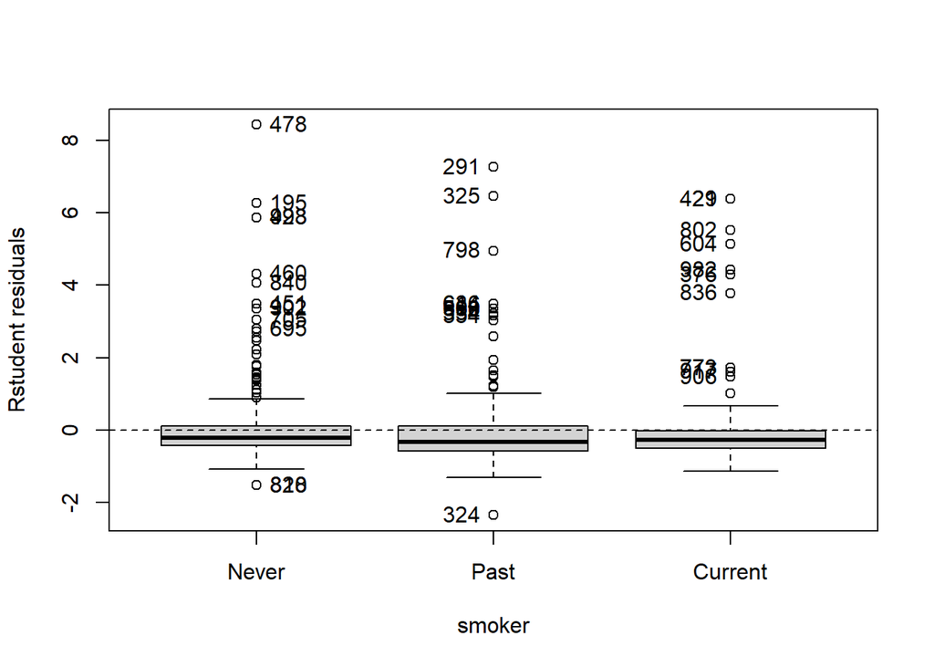

```r
residualPlots(fit1,
              pch=20, col="gray", type = "rstudent",
              fitted = F, tests = F, quadratic = F)
```

You can also use an statistical test for outliers using the `outlierTest()` function, which flags observations with unusually large studentized residuals.

```r
outlierTest(fit1, n.max = Inf)
```

```
##        rstudent unadjusted p-value Bonferroni p
## 207    8.437721         1.1283e-16   1.1283e-13
## 1495   7.270620         7.2289e-13   7.2289e-10
## 2061   6.466775         1.5661e-10   1.5661e-07
## 1659   6.385659         2.6134e-10   2.6134e-07
## 1659.1 6.385659         2.6134e-10   2.6134e-07
## 1310   6.274204         5.2332e-10   5.2332e-07
## 1294   5.878621         5.6397e-09   5.6397e-06
## 1294.1 5.878621         5.6397e-09   5.6397e-06
## 705    5.528305         4.1297e-08   4.1297e-05
## 2175   5.136675         3.3634e-07   3.3634e-04
## 1648   4.957928         8.3713e-07   8.3713e-04
## 1842   4.424519         1.0731e-05   1.0731e-02
## 250    4.320923         1.7095e-05   1.7095e-02
## 342    4.295775         1.9113e-05   1.9113e-02
```

# Influential Observations

Influential observations are ones that alter the regression coefficients by a significant amount when they are included in the model. To test the influence of a point, you can compare the regression coefficient estimates including the point to the ones without including the point in the sample.

Cook’s distance (`cooks.distance()`) is a measure that takes into account the difference in all coefficient estimates when fitting the model with and without the observation in question. Standardized DFBetas (`dfbetas()`) measure the difference for each coefficient estimate separately. The `influenceIndexPlot()` function in the `car` package can plot the Cook’s distance, and the `ols_plot_dfbetas()` function in the `olsrr` package can plot the DFBetas.

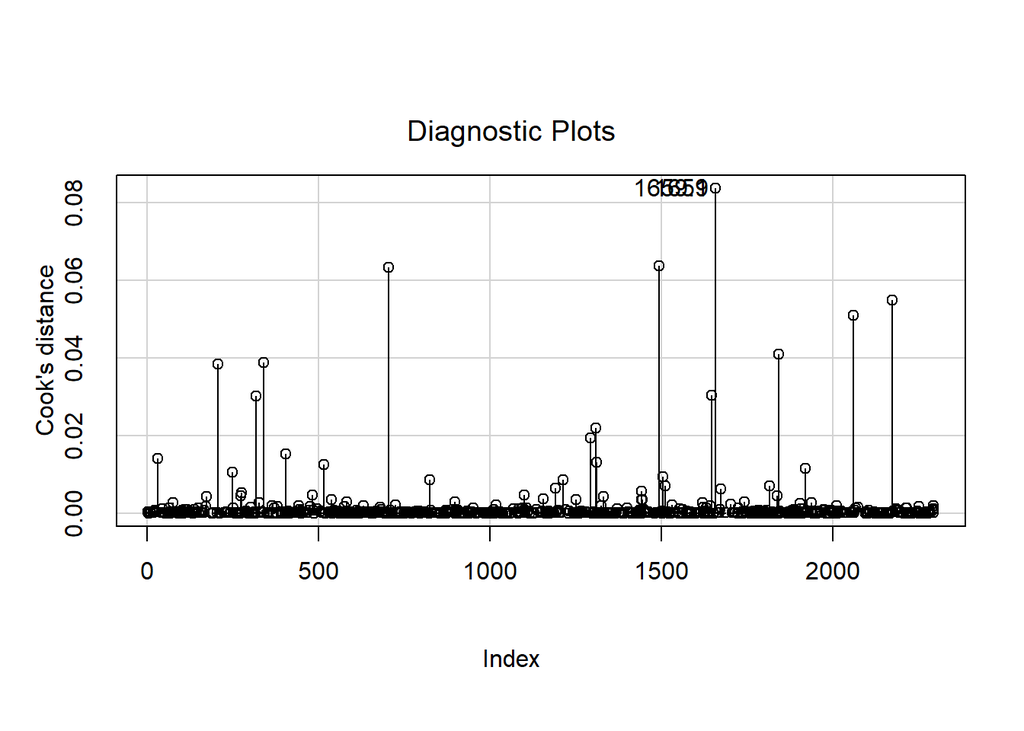

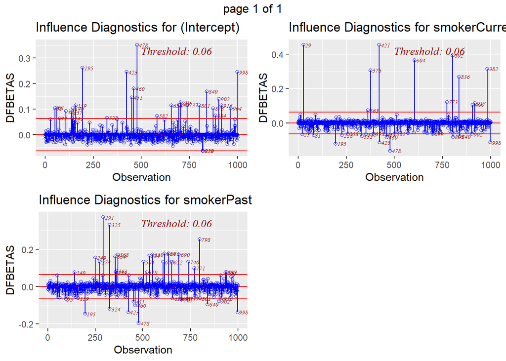

```r
influenceIndexPlot(fit1, vars = "Cook")

ols_plot_dfbetas(fit1)
```

# Continuous Outcome and Two Categorical Predictors

Here we consider 2-way ANOVA with interaction, as described in the class notes. We will use the same outcome from the NHANES data, and use gender (`RIAGENDR`) and cardiovascular disease (`cvd`) as two binary predictors for a simple example.

## Viewing the Group Means

We can look at the group means quantitatively in a table format.

```r
nhanesf %>% group_by(RIAGENDR, cvd) %>%
  summarise(groupmeans = mean(LBDGLUSI))
```

```
## # A tibble: 4 × 3
## # Groups:   RIAGENDR [2]
##   RIAGENDR cvd   groupmeans
##   <fct>    <fct>      <dbl>
## 1 Male     Yes         7.45
## 2 Male     No          6.17
## 3 Female   Yes         6.45
## 4 Female   No          5.88
```

## Running the Model

We can again run this model using the `lm()` function, and adding an interaction term.

```r
fit2 = lm(LBDGLUSI ~ RIAGENDR + cvd + RIAGENDR:cvd, data = nhanesf)
summary(fit2)
```

```
##
## Call:
## lm(formula = LBDGLUSI ~ RIAGENDR + cvd + RIAGENDR:cvd, data = nhanesf)
##
## Residuals:
##     Min      1Q  Median      3Q     Max
## -3.2657 -0.7157 -0.3257  0.1646 12.8346
##
## Coefficients:
##                      Estimate Std. Error t value Pr(>|t|)
## (Intercept)            7.4481     0.2300  32.382  < 2e-16 ***
## RIAGENDRFemale        -0.9941     0.3328  -2.988  0.00288 **
## cvdNo                 -1.2827     0.2428  -5.282 1.57e-07 ***
## RIAGENDRFemale:cvdNo   0.7045     0.3490   2.019  0.04377 *
## ---
## Signif. codes:  0 '***' 0.001 '**' 0.01 '*' 0.05 '.' 0.1 ' ' 1
##
## Residual standard error: 1.577 on 996 degrees of freedom
## Multiple R-squared:  0.04535,    Adjusted R-squared:  0.04248
## F-statistic: 15.77 on 3 and 996 DF,  p-value: 5.012e-10
```

# One Categorical Predictor and One Continuous Predictor

## Visualizing the Relationship

We can create a scatterplot of the outcome vs. the continuous predictor and color by the two diffferent genders. Then we can append best fitting lines to both groups.

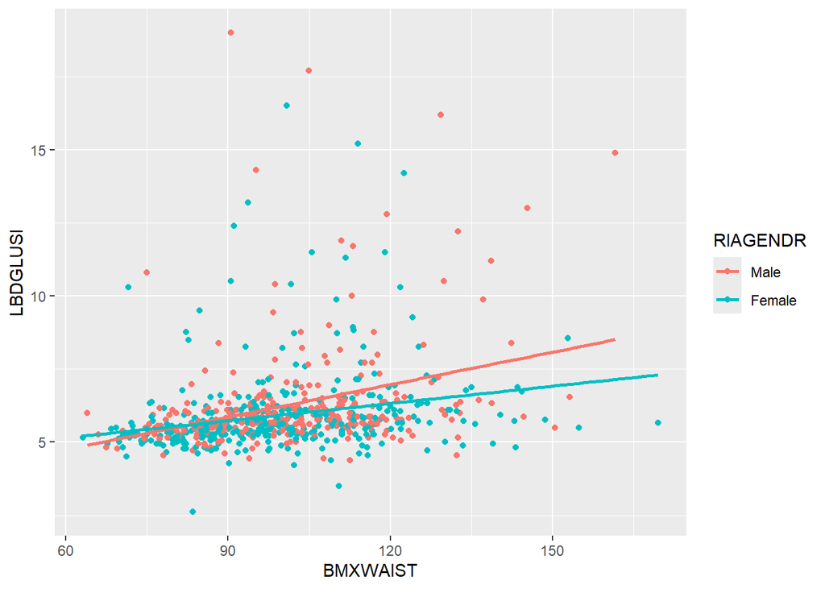

```r
ggplot(data = nhanesf, aes(BMXWAIST, LBDGLUSI, color= RIAGENDR)) +
  geom_point() +
  geom_smooth(method = "lm", se= FALSE)
```

## Running the Model

We can again run this model using the `lm()` function, and adding an interaction term. We can see that the interaction term is statistically significant based on its Wald-type t-test in the summary output.

```r
fit3 = lm(LBDGLUSI ~ RIAGENDR + BMXWAIST + RIAGENDR:BMXWAIST, data = nhanesf)
summary(fit3)
```

```
##
## Call:
## lm(formula = LBDGLUSI ~ RIAGENDR + BMXWAIST + RIAGENDR:BMXWAIST,
##     data = nhanesf)
##
## Residuals:
##     Min      1Q  Median      3Q     Max
## -2.9990 -0.6434 -0.2673  0.1679 13.1196
##
## Coefficients:
##                          Estimate Std. Error t value Pr(>|t|)
## (Intercept)              2.536570   0.451136   5.623 2.46e-08 ***
## RIAGENDRFemale           1.430319   0.593186   2.411   0.0161 *
## BMXWAIST                 0.036949   0.004378   8.440  < 2e-16 ***
## RIAGENDRFemale:BMXWAIST -0.017283   0.005808  -2.976   0.0030 **
## ---
## Signif. codes:  0 '***' 0.001 '**' 0.01 '*' 0.05 '.' 0.1 ' ' 1
##
## Residual standard error: 1.51 on 961 degrees of freedom
##   (35 observations deleted due to missingness)
## Multiple R-squared:  0.1048, Adjusted R-squared:  0.102
## F-statistic:  37.5 on 3 and 961 DF,  p-value: < 2.2e-16
```

## Partial F-Test

We can also test for the significance of the interaction term using a partial F-test comparing the full model to the model without the interaction term. You can do this using the `anova()` function and putting both models (full and reduced) in as arguments. You can see the p-value is the same as for the t-test above.

```r
anova(fit3,
      lm(LBDGLUSI ~ RIAGENDR + BMXWAIST, data = nhanesf))
```

```
## Analysis of Variance Table
##
## Model 1: LBDGLUSI ~ RIAGENDR + BMXWAIST + RIAGENDR:BMXWAIST
## Model 2: LBDGLUSI ~ RIAGENDR + BMXWAIST
##   Res.Df    RSS Df Sum of Sq      F   Pr(>F)
## 1    961 2191.8
## 2    962 2212.0 -1   -20.194 8.8542 0.002997 **
## ---
## Signif. codes:  0 '***' 0.001 '**' 0.01 '*' 0.05 '.' 0.1 ' ' 1
```